# progetto slides

[figure not shown]

*Candidati all'mvp* VS *Resto della lega*, come varia il rendimento dei giocatori tra Regular Season e Playoff

**Il Dataset**

Reso disponibile dalla compagnia *Sports Reference*

https://www.basketball-reference.com/

|  | Rk | Player | Age | Team | Pos | G | GS | MP | FG | FGA | ... | DRB | TRB | AST | STL | BLK | TOV | PF | PTS | Awards | EFF |
| --- | --- | --- | --- | --- | --- | --- | --- | --- | --- | --- | --- | --- | --- | --- | --- | --- | --- | --- | --- | --- | --- |
| 0 | 1 | Shai Gilgeous-Alexander | 26 | OKC | PG | 76 | 76 | 34.2 | 11.3 | 21.8 | ... | 4.1 | 5.0 | 6.4 | 1.7 | 1.0 | 2.4 | 2.2 | 32.7 | MVP-1DPOY-10CPOY-8ASNBA1 | 30.8 |
| 1 | 2 | Giannis Antetokounmpo | 30 | MIL | PF | 67 | 67 | 34.2 | 11.8 | 19.7 | ... | 9.7 | 11.9 | 6.5 | 0.9 | 1.2 | 3.1 | 2.3 | 30.4 | MVP-3DPOY-8ASNBA1 | 33.5 |
| 2 | 3 | Nikola Jokić | 29 | DEN | C | 70 | 70 | 36.7 | 11.2 | 19.5 | ... | 9.9 | 12.7 | 10.2 | 1.8 | 0.6 | 3.3 | 2.3 | 29.6 | MVP-2CPOY-2ASNBA1 | 39.8 |
| 3 | 4 | Luka Dončić | 25 | 2TM | PG | 50 | 50 | 35.4 | 9.2 | 20.5 | ... | 7.4 | 8.2 | 7.7 | 1.8 | 0.4 | 3.6 | 2.5 | 28.2 | NaN | 27.2 |
| 4 | 4 | Luka Dončić | 25 | DAL | PG | 22 | 22 | 35.7 | 9.8 | 21.2 | ... | 7.6 | 8.3 | 7.8 | 2.0 | 0.4 | 3.4 | 2.6 | 28.1 | NaN | 27.7 |
| 5 | 4 | Luka Dončić | 25 | LAL | PG | 28 | 28 | 35.1 | 8.8 | 20.0 | ... | 7.2 | 8.1 | 7.5 | 1.6 | 0.4 | 3.7 | 2.4 | 28.2 | NaN | 26.6 |
| 6 | 5 | Anthony Edwards | 23 | MIN | SG | 79 | 79 | 36.3 | 9.1 | 20.4 | ... | 4.9 | 5.7 | 4.5 | 1.2 | 0.6 | 3.2 | 1.9 | 27.6 | MVP-7CPOY-3ASNBA2 | 22.2 |

7 rows × 32 columns

```
EFF = PTS + TRB + AST + STL + BLK - [TOV + PF + (FGA - FG) + (FTA - FT)]
```

**Domanda 1:** Come varia il rendimento dei giocatori tra Regular Season e Playoff?

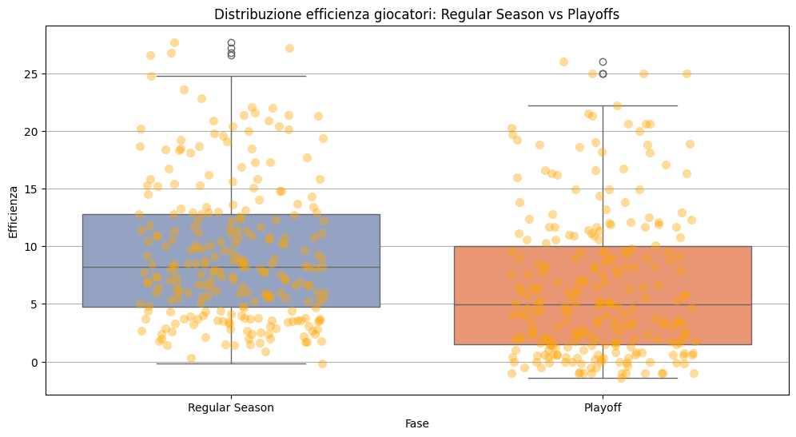

**Domanda 2:** Quali sono le statistiche che calano maggiormente?

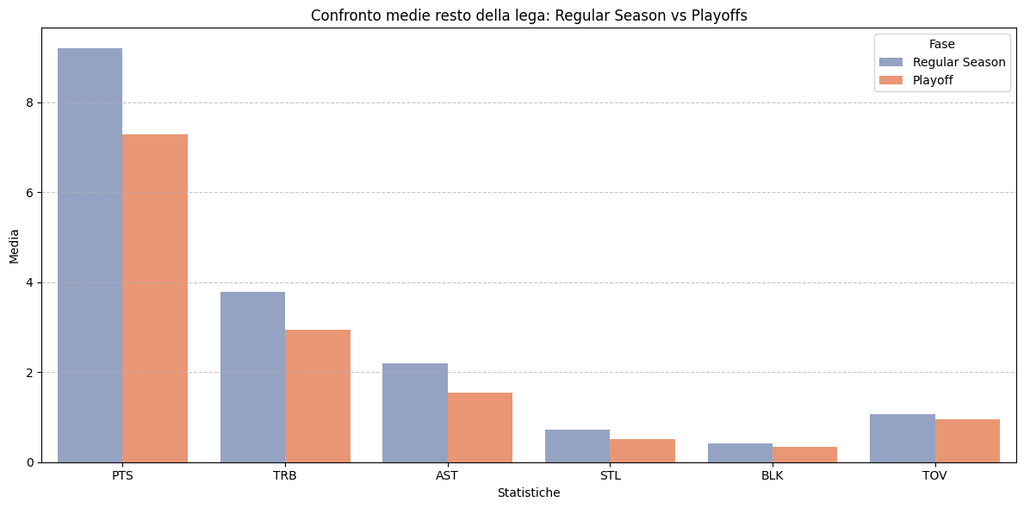

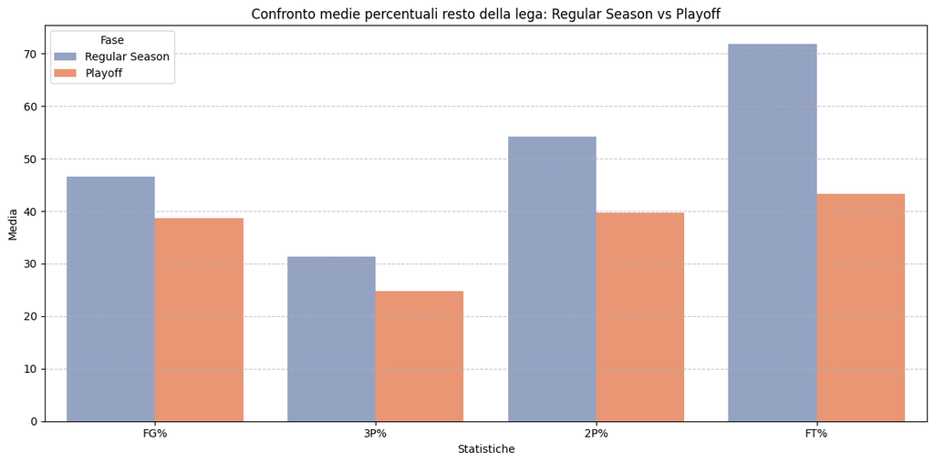

**Domanda 3:** Quali sono i ruoli che risentono maggiormente l'entrata ai playoff?

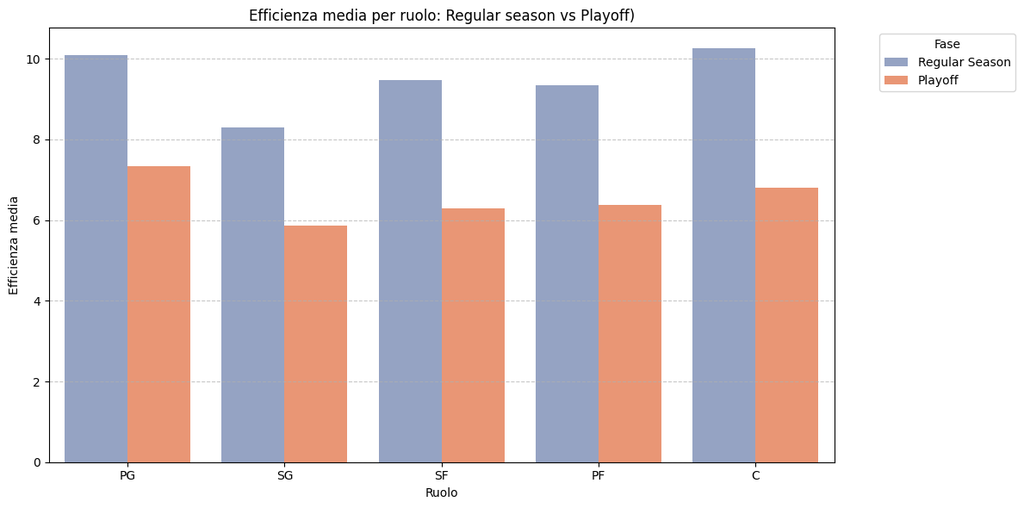

```
Differenza efficienza per ruolo:
C: 3.445
SF: 3.182
PF: 2.978
PG: 2.750
SG: 2.441
```

**Domanda 4:** L'età influisce sul rendimento dei giocatori?

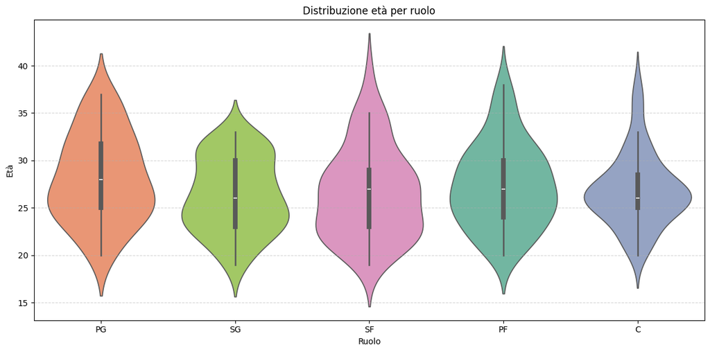

```
Età media per ruolo:
PG: 28.09
PF: 27.39
C: 26.84
SF: 26.58
SG: 26.29
```

**Domanda 5:** I migliori giocatori della lega seguono questi trend o si discostano da essi?

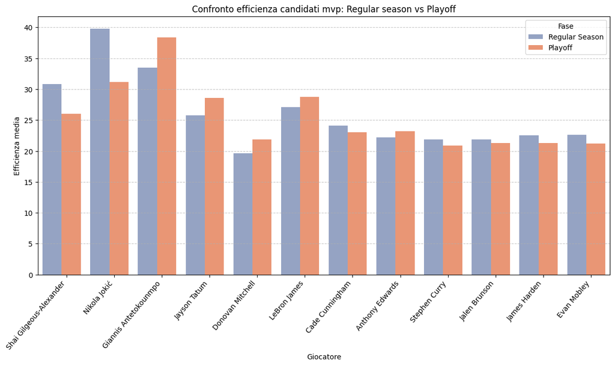

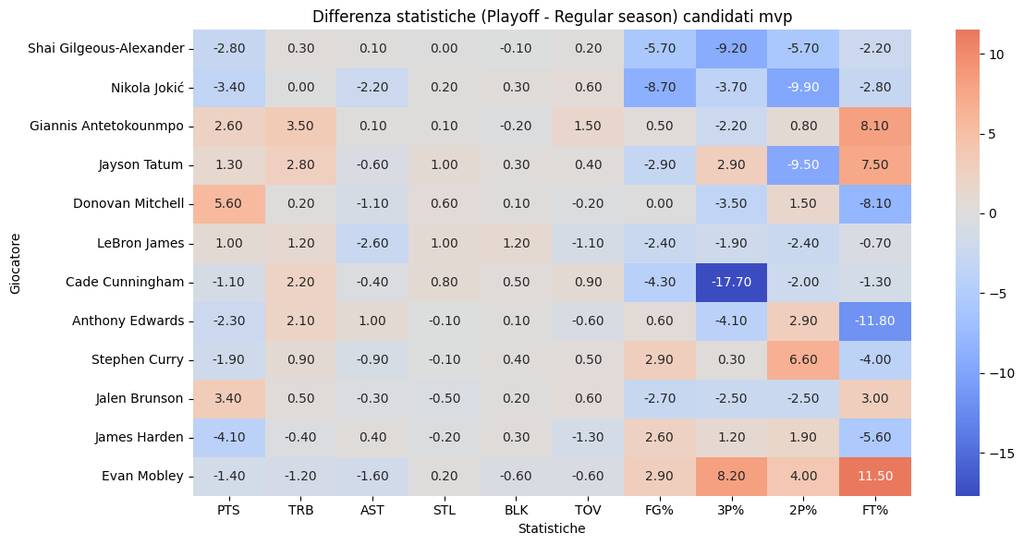

**Conclusioni**

In generale il rendimento di tutti i giocatori della lega cala una volta entrati ai playoff

Ad essere maggiormente penalizzate non sono più di tanto le statistiche quanto più le percentuali

I ruoli più fisici sono quelli che risentono maggiormente il cambio di ritmo dei playoff

I top player riescono a mantenere più stabile il proprio rendimento rispetto al resto della lega

Anche per i top player a calare maggiormente sono le percentuali piuttosto che le statistiche